# Looking at the local data (from the B-IT)

*15-02-2017*

The dataset for GBM that I have downloaded, using the RTCGA package, contains a low number of samples. Ashar mentioned that there is also local GBM data (which is older, so I should be careful), and I could compare the patients in both datasets (look at the overlap).

```r
load("/home/abidata/datasets/patients/GBM_TCGA/clinical.rda")
local_data_clin <- clinical
new_data_clin <- GBM.clinical
local_data_clin$patient <- toupper(local_data_clin$patient)
new_data_clin$patient.bcr_patient_barcode <- toupper(new_data_clin$patient.bcr_patient_barcode)
# View(clinical)
inter <- local_data_clin$patient[local_data_clin$patient %in% new_data_clin$patient.bcr_patient_barcode]
```

```r
length(inter)
```

```
[1] 576
```

```r
nrow(local_data_clin)
```

```
[1] 577
```

```r
nrow(new_data_clin)
```

```
[1] 595
```

```r
library("VennDiagram", lib.loc = "../R/x86_64-pc-linux-gnu-library/3.3")
```

The overlap is very large, but this is only clinical data. The problem with low number of samples was predominantly a problem in miRNASeq and mRNA data:

```r
load("/home/abidata/datasets/patients/GBM_TCGA/miRNAExpression.rda")
load("/home/abidata/datasets/patients/GBM_TCGA/mRNAExpression.rda")
```

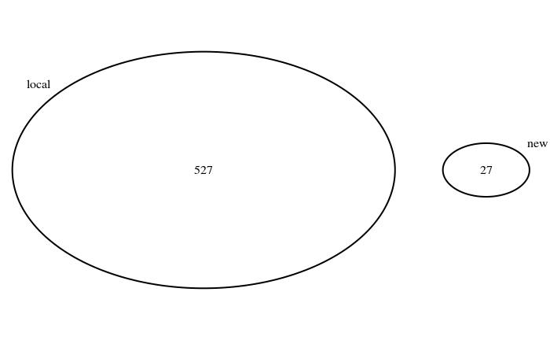

```r
mRNA_new <- toupper(GBM_mRNA$patient_id)
mRNA_old <- toupper(colnames(mRNA))
mRNA_venn <- venn.diagram(list(local = mRNA_old, new = mRNA_new), filename = NULL)
grid.newpage(recording = FALSE)
grid.draw(mRNA_venn, recording = FALSE)
```

Hmm, the intersection is zero. Check if the barcode’s are in the same format:

```r
mRNA_new[1:4]
```

```
[1] "TCGA-CS-4942" "TCGA-CS-4943" "TCGA-CS-4944" "TCGA-CS-5390"
```

```r
mRNA_old[1:4]
```

```
[1] "TCGA-06-0650" "TCGA-76-6193" "TCGA-76-6192" "TCGA-14-0781"
```

It’s not in the same format. Read more about how these barcodes are constructed. I found this image on https://wiki.nci.nih.gov/display/TCGA/TCGA+barcode:

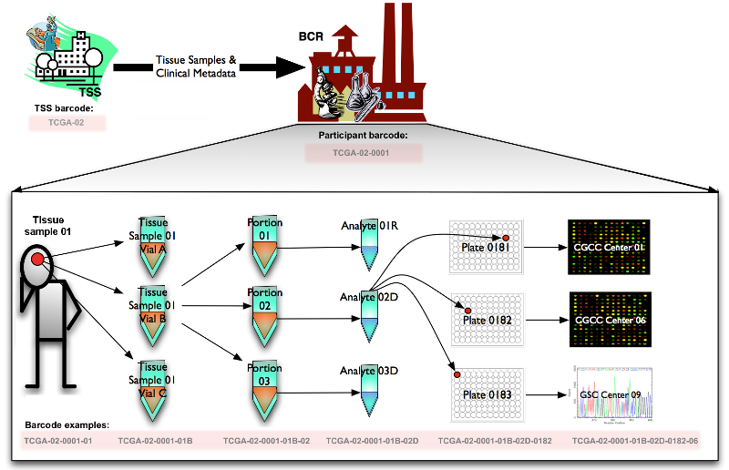

See also this site: https://gdc.cancer.gov/resources-tcga-users/tcga-code-tables/tissue-source-site-codes It seems like the ‘CS’ patients are from a Lower Grade Glioma study (GBMLGG), which is not the same as GMB (I think…). Check this. https://cancergenome.nih.gov/cancersselected/lowergradeglioma: there are indications that LGG is a precursor to the more debilitating GBM.

For miRNA:

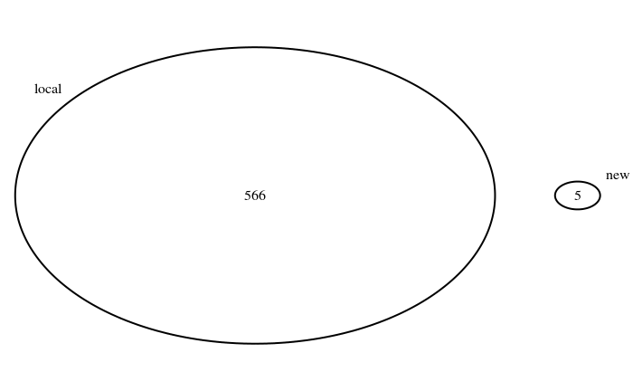

```r
miRNA_new <- toupper(GBM_miRNASeq$patient_id)
miRNA_old <- toupper(colnames(miRNA))
miRNA_venn <- venn.diagram(list(local = miRNA_old, new = miRNA_new), filename = NULL)
grid.newpage(recording = FALSE)
grid.draw(miRNA_venn, recording = FALSE)
```

```r
miRNA_new[1:4]
```

```
[1] "TCGA-06-0675" "TCGA-06-0675" "TCGA-06-0675" "TCGA-06-0678"
```

```r
miRNA_old[1:4]
```

```
[1] "TCGA-16-1063" "TCGA-19-2621" "TCGA-14-0790" "TCGA-06-0122"
```

*16-02-2017*

I think it is a good idea to use the local mRNA and miRNA data, together with the new clinical data. The newer clinical data might have updated “days to death” variables, and almost all patients from the old dataset are also in the newer (clinical) dataset.

Oh wait, I just realized, I might be comparing mRNASeq data with mRNA (micro array) data and idem for miRNA. For miRNA, there is only Seq data available but the local data seems to be micro array data.

I could combine the local miRNA data with the new clinical data. First see how large the overlap is:

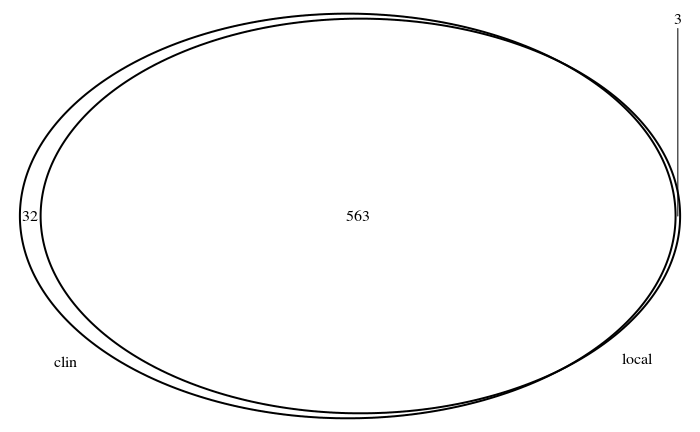

```r
miRNA_clin <- toupper(new_data_clin$patient.bcr_patient_barcode)
miRNA_old <- toupper(colnames(miRNA))
miRNA_venn <- venn.diagram(list(local = miRNA_old, clin = miRNA_clin), filename = NULL)
grid.newpage(recording = FALSE)
grid.draw(miRNA_venn, recording = FALSE)
```

This looks good, almost all patients in the clinical dataset have (local) miRNA data.

```r
GBM_inter <- FindIntersection(omics, "GBM", save = FALSE)
```

```
the condition has length > 1 and only the first element will be used
```